# Time series theory (1/2)

# 1 Packages

This notebook provides both R & Python code. The language tabs are synchronized throughout the document. Both languages execute from top to bottom (imperatively sequentially).

Quarto uses **knitr** and **reticulate** to execute both languages. Install any missing R packages from the list below, including reticulate (1.41 or later). The loading chunk declares Python dependencies, including the Excel reader, for reticulate’s managed environment.

Install the Python dependencies with `python -m pip install numpy pandas matplotlib seaborn scipy statsmodels requests openpyxl yfinance plotly`.  
If necessary, set `RETICULATE_PYTHON` to your Python interpreter path before starting Quarto. Render with `quarto render 2_theory_1_R_Python.qmd`.

Both languages use a seed of 42, but their random generators produce different samples.  
Simulation plots and test outcomes can therefore differ across languages.  
The Python examples load their own data and can be followed independently of R.

**R**

```r
library(tidyverse)  # THE library for data science
library(openxlsx)   # A cool package to deal with Excel files/formats
library(quantmod)   # Package for financial data extraction
library(tsibble)    # TS with dataframes framework
library(fable)      # Package for time-series models & predictions
library(feasts)     # Package for time-series analysis
library(forecast)   # Another package for TS (forecasting)
library(tseries)    # Simple package for time-series tests
library(plotly)     # For 3D graphs
library(mvtnorm)    # For multivariate Gaussian distributions

reticulate::py_require(c(
  "numpy", "pandas", "matplotlib", "seaborn", "scipy", "statsmodels",
  "requests", "openpyxl>=3.1.5", "yfinance", "plotly"
))
set.seed(42)        # Random seed
```

**Python**

```python
import io
import numpy as np
import pandas as pd
import openpyxl  # Excel reader used by pandas.
import matplotlib.pyplot as plt
import seaborn as sns
import requests
import yfinance as yf
import plotly.graph_objects as go
from scipy import stats
from statsmodels.tsa.stattools import adfuller, kpss
from statsmodels.tsa.seasonal import STL

rng = np.random.default_rng(42)
sns.set_theme(style="whitegrid")
```

Time-series models are entirely built to capture and mimic the **randomness** which we observe in real life situations.  
Hence, understanding randomness is key.

# 2 Random variables

**Random variables** are mathematical tools (formalizations) that characterize, quite naturally, realizations of events that cannot be exactly predicted, for which there is some form of **uncertainty**.

To introduce key concepts, we will proceed with **basic case studies**.

## 2.1 Example 1: the coin toss

### 2.1.1 Fair

Perhaps the most simple (and easy to understand) example is the **tossing of coins**.  
Let’s first suppose that the coin is not biased and that there is a 50% of obtaining *heads* or *tails*.  
We can simulate this with a computer. Below, let’s way that

- 0 = *heads*
- 1 = *tails*

Let’s repeat the process 10 times:

**R**

```r
coins <- rbinom(10, 1, 0.5)
coins
```

```
 [1] 1 1 0 1 1 1 1 0 1 1
```

**Python**

```python
coins = rng.binomial(n=1, p=0.5, size=10)
print(coins)
```

```
[1 0 1 1 0 1 1 1 0 0]
```

Now, the most important concept with random variables has to do with the frequency of their realizations.  
This is often referred to as the **probability** that an event can occur.  
In the case of a coin toss, there are only two possible outcomes. Hence, the representation of probabilities is easy (two numbers).

**R**

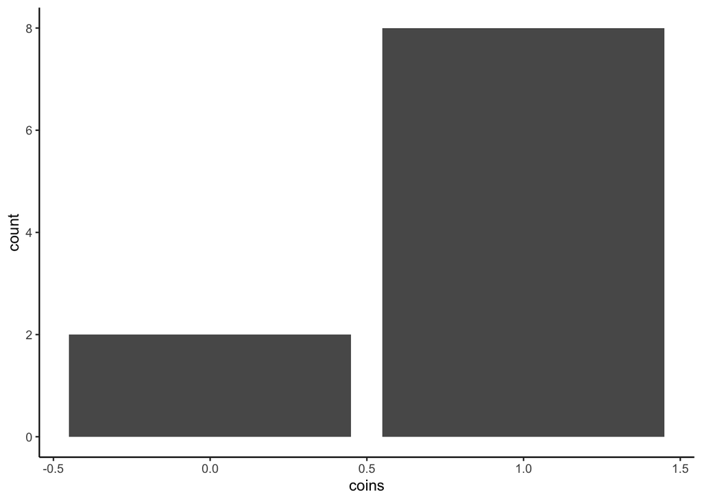

```r
tibble(coins = coins) |> ggplot(aes(x = coins)) + theme_classic() + geom_bar()
```

**Python**

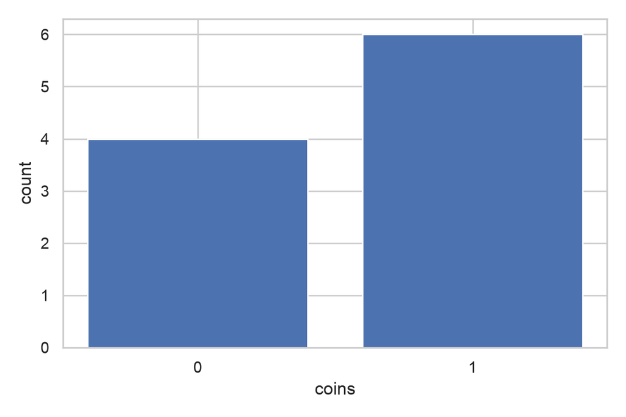

```python
fig, ax = plt.subplots(figsize=(6, 4))
ax.bar([0, 1], np.bincount(coins, minlength=2))
ax.set(xlabel="coins", ylabel="count", xticks=[0, 1])
fig.tight_layout()
plt.show()
```

Now, the particular random draw is somewhat surprising. We would expect something closer to 50%/50%.  
But that’s the game of random draws!

In order to get a more balanced result for with high likelihood, there is only one way: to consider much more than 10 draws.

**R**

```r
coins <- rbinom(100, 1, 0.5)
coins
```

```
  [1] 0 1 1 0 0 1 1 0 0 1 1 0 1 1 0 1 0 1 0 1 1 1 0 1 0 1 0 0 1 1 0 0 0 1 0 1 1
 [38] 1 1 1 0 0 0 1 0 1 1 0 0 1 1 1 1 1 1 0 0 1 1 0 0 0 0 0 0 1 0 0 1 0 1 0 0 1
 [75] 1 1 0 0 0 0 1 0 0 1 1 1 0 1 1 1 1 0 0 0 1 1 1 1 1 0
```

**Python**

```python
coins = rng.binomial(n=1, p=0.5, size=100)
print(coins)
```

```
[0 1 1 1 0 0 1 0 1 1 1 0 1 1 1 0 0 0 0 1 1 1 0 0 0 0 0 0 0 1 0 1 1 0 1 1 0
 0 1 0 0 0 1 1 1 1 0 1 0 0 1 0 1 1 1 1 1 0 0 0 0 0 1 0 0 0 0 1 1 1 1 0 1 0
 0 0 1 0 0 1 0 1 0 0 0 1 0 0 0 1 1 1 0 1 1 1 0 0 0 1]
```

Et voilà!

**R**

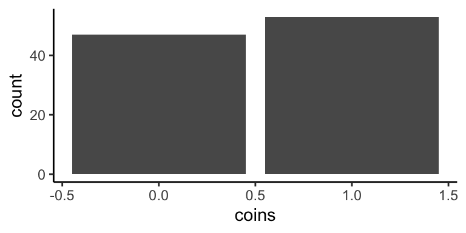

```r
tibble(coins = coins) |> ggplot(aes(x = coins)) + theme_classic() + geom_bar()
```

**Python**

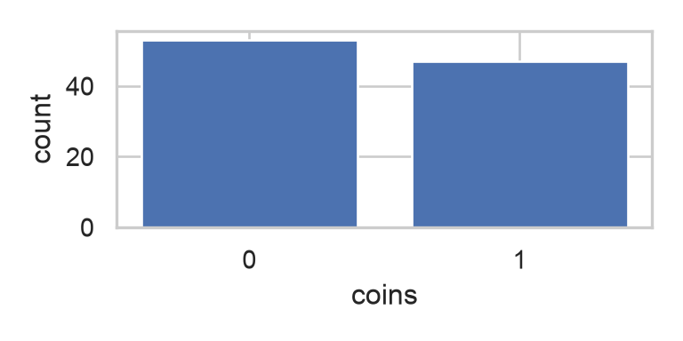

```python
fig, ax = plt.subplots(figsize=(4, 2))
ax.bar([0, 1], np.bincount(coins, minlength=2))
ax.set(xlabel="coins", ylabel="count", xticks=[0, 1])
fig.tight_layout()
plt.show()
```

As the number of draws increases, the frequency will slowly converge to 50%/50%.

### 2.1.2 Biased

It’s also possible to imagine a **biased** coin.

**R**

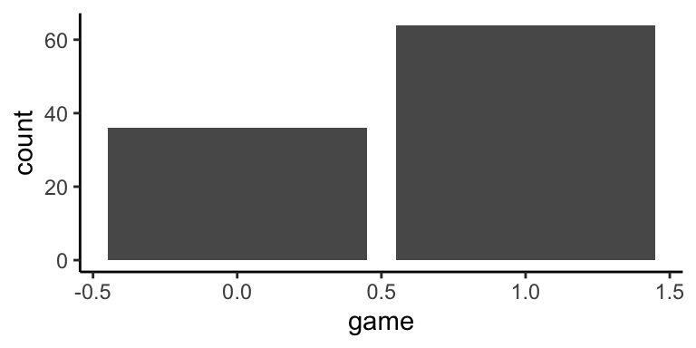

```r
game <- rbinom(100, 1, 0.7)
tibble(game = game) |> ggplot(aes(x = game)) + theme_classic() + geom_bar()
```

**Python**

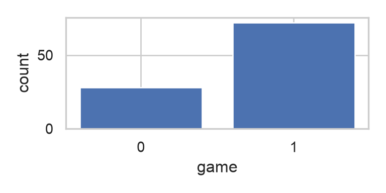

```python
game = rng.binomial(n=1, p=0.7, size=100)
fig, ax = plt.subplots(figsize=(4, 2))
ax.bar([0, 1], np.bincount(game, minlength=2))
ax.set(xlabel="game", ylabel="count", xticks=[0, 1])
fig.tight_layout()
plt.show()
```

## 2.2 Example 2: rolling a dice

Ok, so coin tossing is easy and overly simplistic. Let’s consider a more complex setting in which more than two outcomes are possible.

Rolling dice seems like a perfect choice!

**R**

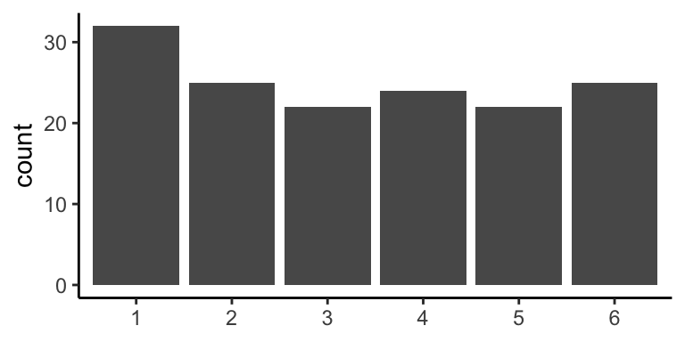

```r
rolls <- replicate(150, sample(1:6, 1, replace = TRUE))
tibble(rolls = rolls) |>
  ggplot(aes(x = as.factor(rolls))) + geom_bar() + theme_classic() +
  theme(axis.title.x = element_blank())
```

**Python**

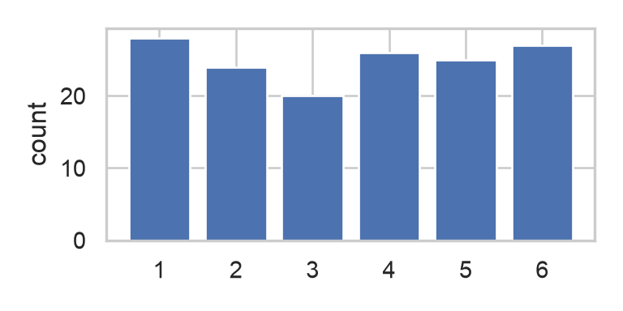

```python
rolls = rng.integers(1, 7, size=150)
fig, ax = plt.subplots(figsize=(4, 2))
ax.bar(np.arange(1, 7), np.bincount(rolls, minlength=7)[1:])
ax.set(xlabel="", ylabel="count", xticks=np.arange(1, 7))
fig.tight_layout()
plt.show()
```

In the above graph, the bars represent the number of times that each outcome is produced.  
If we want frequencies/probabilities instead of counts, we need to divide by the number of draws.

**R**

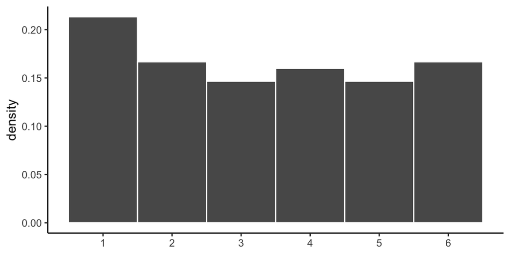

```r
tibble(rolls = rolls) |>
  ggplot(aes(x = rolls)) +
  geom_histogram(breaks = seq(0.5, 6.5, by = 1), aes(y = after_stat(density)), color = "white") +
  theme_classic() + theme(axis.title.x = element_blank()) +
  scale_x_continuous(breaks = 0:6)
```

**Python**

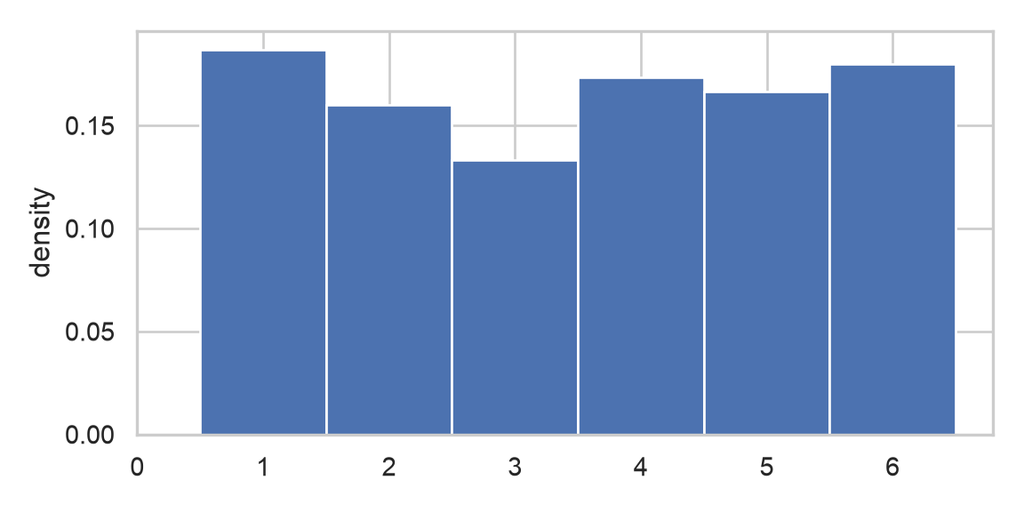

```python
# Unit-width bins make density equal to relative frequency.
fig, ax = plt.subplots(figsize=(6, 3))
ax.hist(rolls, bins=np.arange(0.5, 7, 1), density=True, edgecolor="white")
ax.set(xlabel="", ylabel="density", xticks=np.arange(7))
fig.tight_layout()
plt.show()
```

## 2.3 Example 3: distribution of sizes

Ok but let’s push even further.  
Imagine we were to ask every person in one country his or her size (say, in centimeters). If we pick the individual randomly, this makes one draw of a random variable. We can visualize this! We point to three sources:

- [Our World in Data](https://ourworldindata.org/human-height), though the data is quite old (1996) but ok for long-term perspectives;
- [World Data](https://www.worlddata.info/average-bodyheight.php) - much more recent & up-to-date (2022);
- The [CDC](https://www.cdc.gov/nchs/fastats/body-measurements.htm) in the US reports slightly different values.

**R**

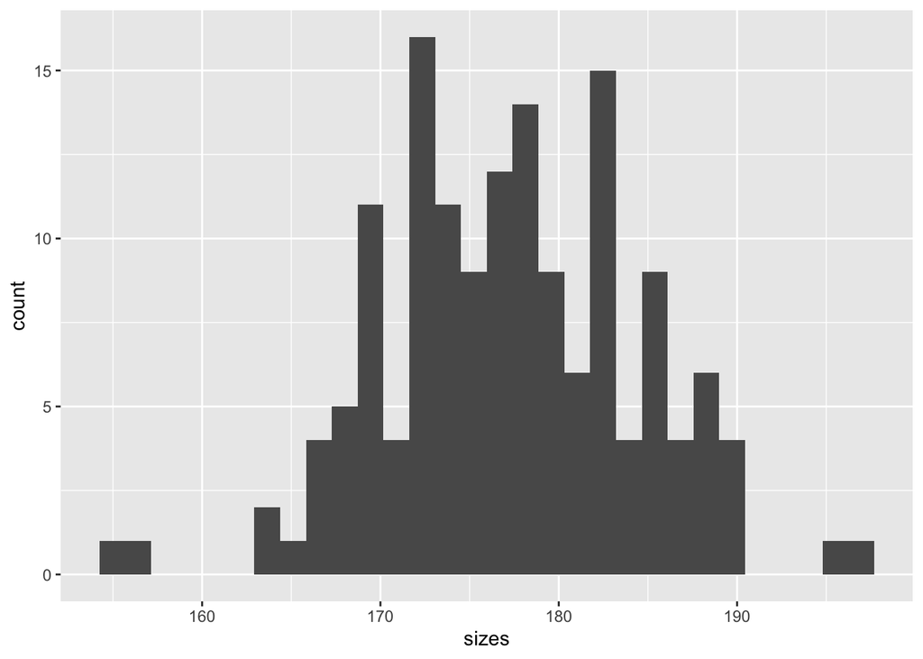

```r
sizes <- rnorm(150, mean = 178, sd = 7) |> round()
tibble(sizes = sizes) |> ggplot(aes(x = sizes)) + geom_histogram()
```

**Python**

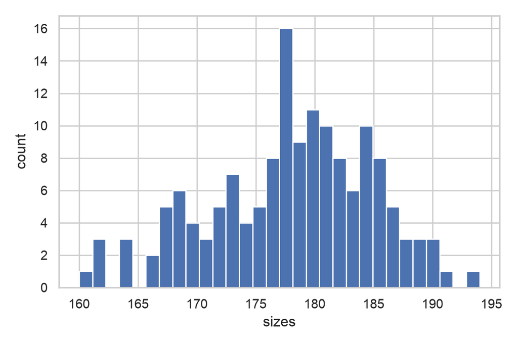

```python
sizes = np.round(rng.normal(loc=178, scale=7, size=150))
fig, ax = plt.subplots(figsize=(6, 4))
ax.hist(sizes, bins=30, edgecolor="white")
ax.set(xlabel="sizes", ylabel="count")
fig.tight_layout()
plt.show()
```

There are holes if the sample is small…

A larger sample reveals the underlying distribution more clearly. These simulated heights look Gaussian because we generated them from a normal distribution.

**R**

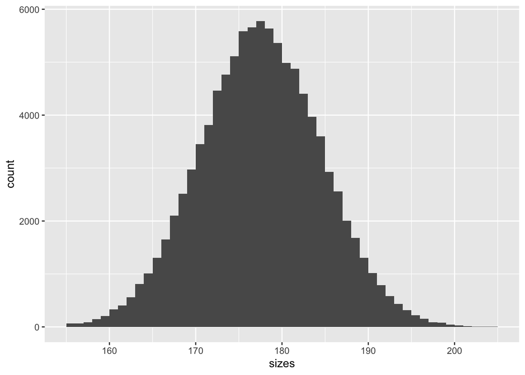

```r
sizes <- rnorm(10^5, mean = 178, sd = 7) |> round()
tibble(sizes = sizes) |> ggplot(aes(x = sizes)) + geom_histogram(breaks = 155:205)
```

**Python**

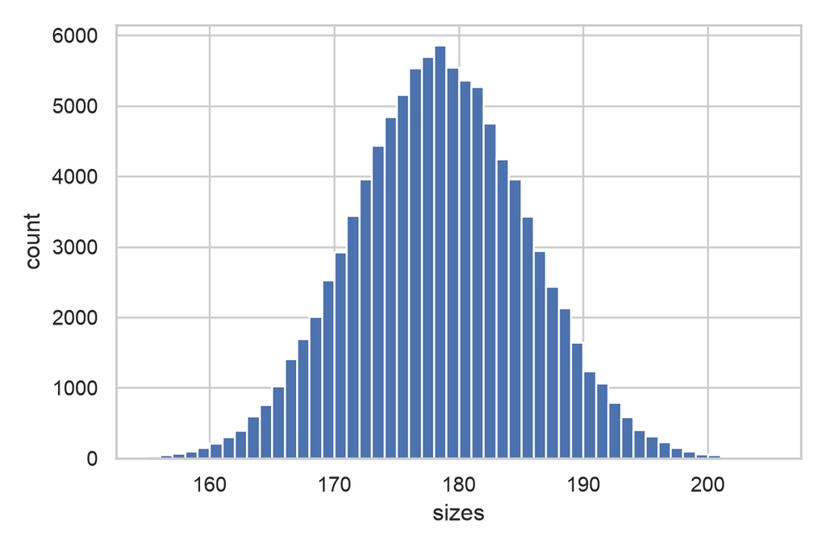

```python
sizes = np.round(rng.normal(loc=178, scale=7, size=100_000))
fig, ax = plt.subplots(figsize=(6, 4))
ax.hist(sizes, bins=np.arange(155, 206), edgecolor="white")
ax.set(xlabel="sizes", ylabel="count")
fig.tight_layout()
plt.show()
```

## 2.4 The Gaussian distribution

Let’s spend a bit of time on the properties of this very (very) important distribution.  
It is entirely defined by two parameters:

- its **mean** (average)
- its **variance** (uncertainty)

**R**

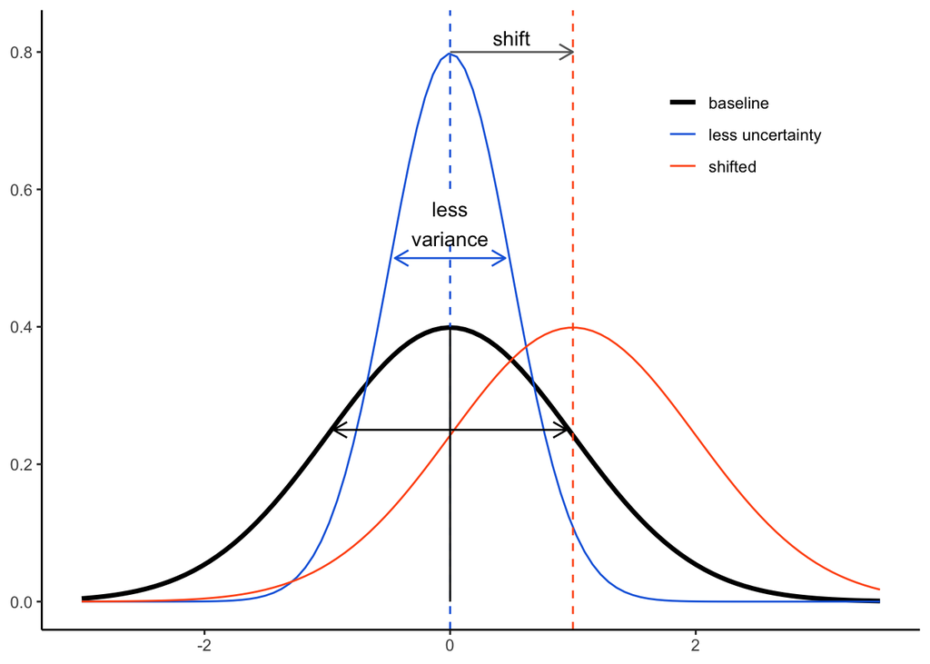

```r
ggplot() + xlim(-3,3.5) + theme_classic() +
  geom_function(fun = dnorm, args = list(mean = 0, sd = 1), aes(color = "baseline"), linewidth = 1.2) +
  geom_function(fun = dnorm, args = list(mean = 0, sd = 0.5), aes(color = "less uncertainty")) +
  geom_function(fun = dnorm, args = list(mean = 1, sd = 1), aes(color = "shifted")) +
  theme(legend.position = c(0.8,0.8),
        axis.title = element_blank(),
        legend.title = element_blank()) +
  scale_color_manual(values = c("#000", "#1166DD", "#FF5511")) +
  geom_vline(xintercept = 0, linetype = 2, color = "#1166DD") +
  geom_vline(xintercept = 1, linetype = 2, color = "#FF5511") +
  geom_segment(aes(x = -0.45, y = 0.5, xend = 0.45, yend = 0.5), color = "#1166DD",
               arrow = arrow(length = unit(0.3, "cm"), ends = "both")) +
  geom_segment(aes(x = -0.95, y = 0.25, xend = 0.95, yend = 0.25), color = "black",
               arrow = arrow(length = unit(0.3, "cm"), ends = "both")) +
  geom_segment(aes(x = 0, y = 0.8, xend = 1, yend = 0.8), color = "#666666",
               arrow = arrow(length = unit(0.3, "cm"))) +
  annotate("text", x = 0.5, y = 0.82, label = "shift") +
  annotate("rect", fill = "white", xmin = -0.37, xmax = 0.37, ymin = 0.52, ymax = 0.60) +
  annotate("text", x = 0, y = 0.55, label = "less\nvariance") +
  geom_segment(aes(x = 0, y = 0, yend = 0.4, xend = 0), linetype = 1)
```

**Python**

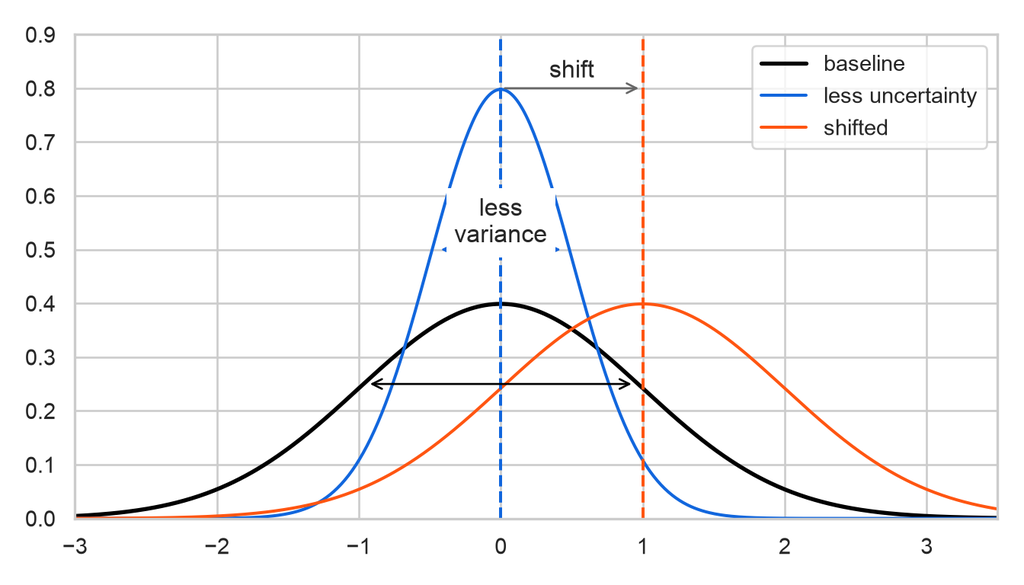

```python
x_grid = np.linspace(-3, 3.5, 500)
fig, ax = plt.subplots(figsize=(7, 4))
ax.plot(x_grid, stats.norm.pdf(x_grid, loc=0, scale=1),
        color="black", linewidth=2, label="baseline")
ax.plot(x_grid, stats.norm.pdf(x_grid, loc=0, scale=0.5),
        color="#1166DD", label="less uncertainty")
ax.plot(x_grid, stats.norm.pdf(x_grid, loc=1, scale=1),
        color="#FF5511", label="shifted")
ax.axvline(0, color="#1166DD", linestyle="--")
ax.axvline(1, color="#FF5511", linestyle="--")
for left, right, height, color in [(-0.45, 0.45, 0.5, "#1166DD"),
                                    (-0.95, 0.95, 0.25, "black")]:
    ax.annotate("", xy=(right, height), xytext=(left, height),
                arrowprops={"arrowstyle": "<->", "color": color})
ax.annotate("", xy=(1, 0.8), xytext=(0, 0.8),
            arrowprops={"arrowstyle": "->", "color": "#666666"})
ax.text(0.5, 0.82, "shift", ha="center")
ax.text(0, 0.55, "less\nvariance", ha="center", va="center",
        bbox={"facecolor": "white", "edgecolor": "none"})
ax.set(xlabel="", ylabel="", xlim=(-3, 3.5), ylim=(0, 0.9))
ax.legend(loc="upper right")
fig.tight_layout()
plt.show()
```

In 95%+ of models this is the distribution that is used to generate randomness.

Ok but how can I know if my data is distributed according to a normal law?

- There are plenty of tests ([Shapiro-Wilk](https://en.wikipedia.org/wiki/Shapiro%E2%80%93Wilk_test), [Kolmogorov-Smirnov](https://en.wikipedia.org/wiki/Kolmogorov%E2%80%93Smirnov_test));
- But a **visual confirmation** is often enough!

The simplest way is to produce a QQ-plot (quantile-versus-quantile) to see if the empirical distribution matches (is close to) the Gaussian one. Below it seems “ok” - with some outliers nonetheless. Another appraoch is simply to display the **histogram** and see if it is “*bell-shaped*”.

**R**

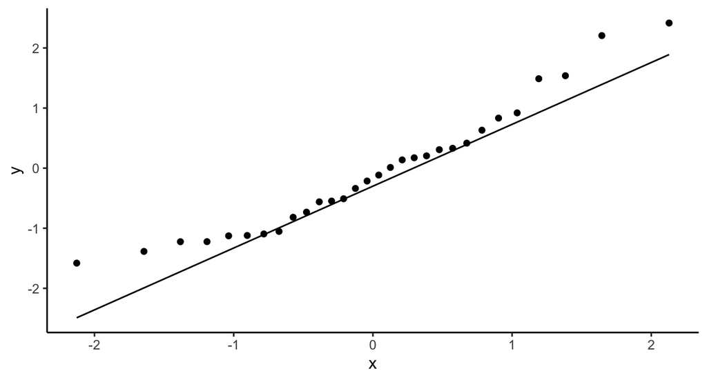

```r
data.frame(x = rnorm(30)) |>
  ggplot(aes(sample = x)) + theme_classic() + stat_qq() + stat_qq_line()
```

**Python**

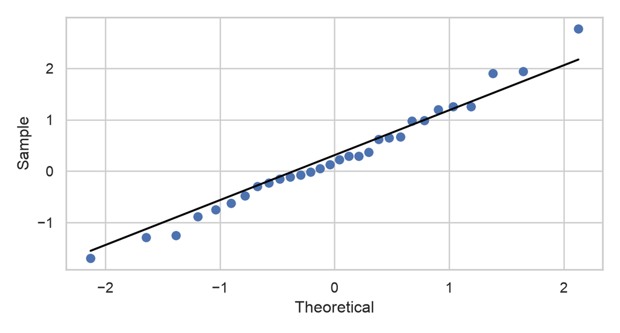

```python
qq_sample = rng.normal(size=30)
fig, ax = plt.subplots(figsize=(6.5, 3.5))
# R's stat_qq_line uses the first and third sample quartiles.
theoretical = stats.norm.ppf((np.arange(1, len(qq_sample) + 1) - 0.5) / len(qq_sample))
q_theory = stats.norm.ppf([0.25, 0.75])
q_sample = np.quantile(qq_sample, [0.25, 0.75])
slope = np.diff(q_sample)[0] / np.diff(q_theory)[0]
intercept = q_sample[0] - slope * q_theory[0]
ax.scatter(theoretical, np.sort(qq_sample))
ax.plot(theoretical, intercept + slope * theoretical, color="black")
ax.set(xlabel="Theoretical", ylabel="Sample")
fig.tight_layout()
plt.show()
```

But with an exponential distribution…

**R**

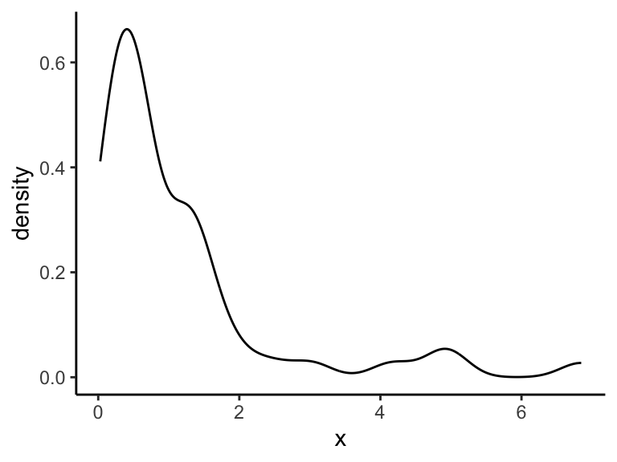

```r
set.seed(42)
data.frame(x = rexp(50)) |> ggplot(aes(x = x)) + theme_classic() + geom_density()
```

**Python**

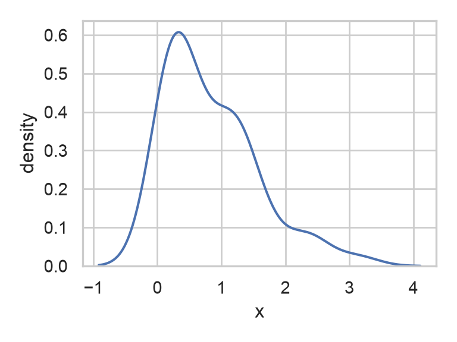

```python
rng = np.random.default_rng(42)
exponential_sample = rng.exponential(scale=1, size=50)
fig, ax = plt.subplots(figsize=(4, 3))
sns.kdeplot(x=exponential_sample, ax=ax)
ax.set(xlabel="x", ylabel="density")
fig.tight_layout()
plt.show()
```

**R**

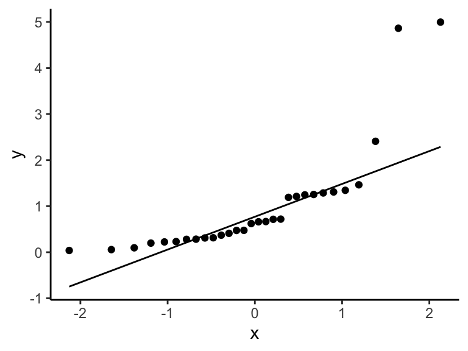

```r
set.seed(42)
data.frame(x = rexp(30)) |> ggplot(aes(sample = x)) + theme_classic() + stat_qq() + stat_qq_line()
```

**Python**

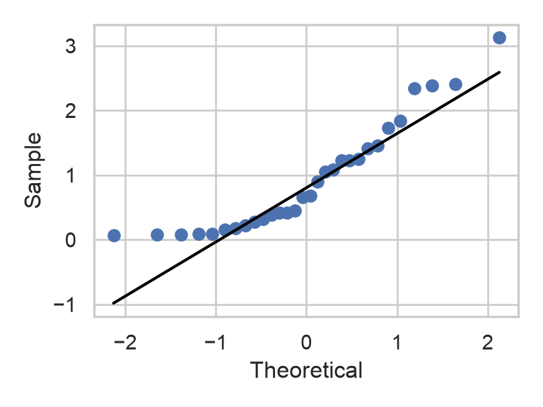

```python
rng = np.random.default_rng(42)
qq_sample = rng.exponential(scale=1, size=30)
theoretical = stats.norm.ppf((np.arange(1, len(qq_sample) + 1) - 0.5) / len(qq_sample))
q_theory = stats.norm.ppf([0.25, 0.75])
q_sample = np.quantile(qq_sample, [0.25, 0.75])
slope = np.diff(q_sample)[0] / np.diff(q_theory)[0]
intercept = q_sample[0] - slope * q_theory[0]
fig, ax = plt.subplots(figsize=(4, 3))
ax.scatter(theoretical, np.sort(qq_sample))
ax.plot(theoretical, intercept + slope * theoretical, color="black")
ax.set(xlabel="Theoretical", ylabel="Sample")
fig.tight_layout()
plt.show()
```

## 2.5 Multivariate distributions

In fact, random variables may come by pairs, or triplets, or more! For instance, we could imagine to study weight in addition to height!  
In this case, representations are more complex of course and an important concept is that of **covariance**:

$$\text{Cov}(X_1, X_2) = \mathbb{E[(X_1-\mu_1)(X_2-\mu_2)]},$$

Let us show a (stylized) example below. To see how correlation affects the density, it’s imperative to play with the 3D representation. We increase the correlation on purpose to show its effect.

**R**

```r
mu <- c(178, 79)  # mean vector
sigma <- 9*matrix(c(1, 0.7, 0.7, 1), nrow = 2)  # covariance matrix

# Create grid of x and y values
x <- mu[1] + seq(-7, 7, length.out = 100)
y <- mu[2] + seq(-7, 7, length.out = 100)
grid <- expand.grid(x = x, y = y)
z <- dmvnorm(as.matrix(grid), mean = mu, sigma = sigma)
z_matrix <- matrix(z, nrow = length(x), ncol = length(y))

plot_ly(x = ~x, y = ~y, z = ~z_matrix) %>%
  add_surface(colorscale = "Viridis") %>%
  layout(
    scene = list(
      xaxis = list(title = "Height (cm)"),
      yaxis = list(title = "Weight (kgs)"),
      zaxis = list(title = "Density"),
      camera = list(eye = list(x = 1.5, y = -1.5, z = 1.25))
    )
  )
```

[interactive chart not shown]

**Python**

```python
mu = np.array([178, 79])
sigma = 9 * np.array([[1, 0.7], [0.7, 1]])
x_grid = mu[0] + np.linspace(-7, 7, 100)
y_grid = mu[1] + np.linspace(-7, 7, 100)
X, Y = np.meshgrid(x_grid, y_grid)
positions = np.stack([X, Y], axis=-1)
Z_density = stats.multivariate_normal.pdf(positions, mean=mu, cov=sigma)
fig = go.Figure(go.Surface(x=x_grid, y=y_grid, z=Z_density, colorscale="Viridis"))
fig.update_layout(
    scene={"xaxis_title": "Height (cm)", "yaxis_title": "Weight (kgs)",
           "zaxis_title": "Density",
           "camera": {"eye": {"x": 1.5, "y": -1.5, "z": 1.25}}},
    margin={"l": 0, "r": 0, "t": 20, "b": 0}, height=450,
);
fig
```

[interactive chart not shown]

To visualize correlation, the simplest way is to use a **scatterplot** with one variable on one axis and the other on the other!  
The correlation is linked to the **slope** of the regression line: strong positive (*resp.* negative) slope implies positive (*resp.* negative) correlation. When the line is roughly flat, the variables do not co-move together: correlation is weak or null.

**R**

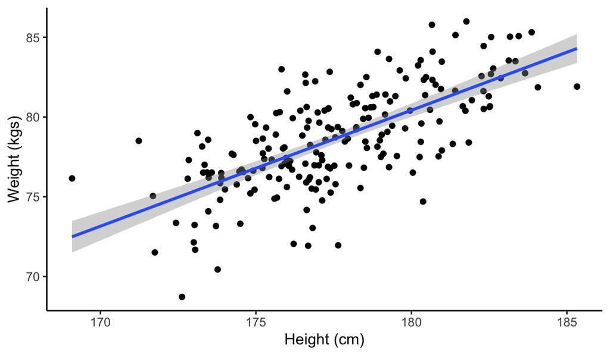

```r
Z <- rmvnorm(200, mean = mu, sigma = sigma)
data.frame(x = Z[,1], y = Z[,2]) |>
  ggplot(aes(x = x, y = y)) + geom_point() + labs(x = "Height (cm)", y = "Weight (kgs)") +
  theme_classic() + geom_smooth(method = "lm")
```

**Python**

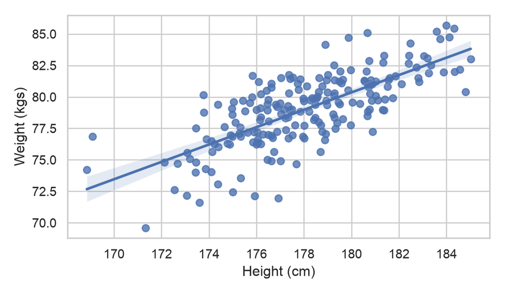

```python
Z = rng.multivariate_normal(mean=mu, cov=sigma, size=200)
fig, ax = plt.subplots(figsize=(6, 3.5))
sns.regplot(x=Z[:, 0], y=Z[:, 1], ci=95, seed=42, ax=ax)
ax.set(xlabel="Height (cm)", ylabel="Weight (kgs)")
fig.tight_layout()
plt.show()
```

## 2.6 Moments (descriptive statistics)

The most simple (and insightful) ways to characterize distributions:

- the **mean**
- the **variance** and standard deviation
- the correlation (for 2+ variables)

**NoteThe mean**

The most important indicator (fun fact: it’s not always defined/finite!)

- **discrete** distribution: $\mathbb{E}[X] = \sum_{k=0}^\infty kP[X=k]$;
- **continuous** distribution: $\mathbb{E}[X] = \int_\mathbb{R} x f(x)dx,$

where $f(x) = \frac{d}{dx}P[X \le x]$ is the **density** of the variable.

In R, use `mean(x)`; in Python, use `np.mean(x)`.

**NoteThe variance**

The second most important indicator.

- **discrete** distribution: $\mathbb{V}[X] = \sum_{k=0}^\infty (k-m)^2P[X=k]$;
- **continuous** distribution: $\mathbb{V}[X] = \int_\mathbb{R} (x-m)^2 f(x)dx,$

where $m$ is the **mean** of the variable.

In R, use `var(x)` or `sd(x)`. In Python, use `np.var(x, ddof=1)` or `np.std(x, ddof=1)` to match R’s sample variance and standard deviation.

## 2.7 LLN versus CLT

Assume IID observations with mean $\mu$ and finite positive variance $\sigma^2$. Here, individual observations follow an exponential distribution, so $\mu=\sigma=1$.

### 2.7.1 Averages slowly stabilize

The **law of large numbers** describes convergence of the sample average:
$$\bar X_n=\frac{1}{n}\sum_{i=1}^n X_i \xrightarrow{p}\mu.$$

**R**

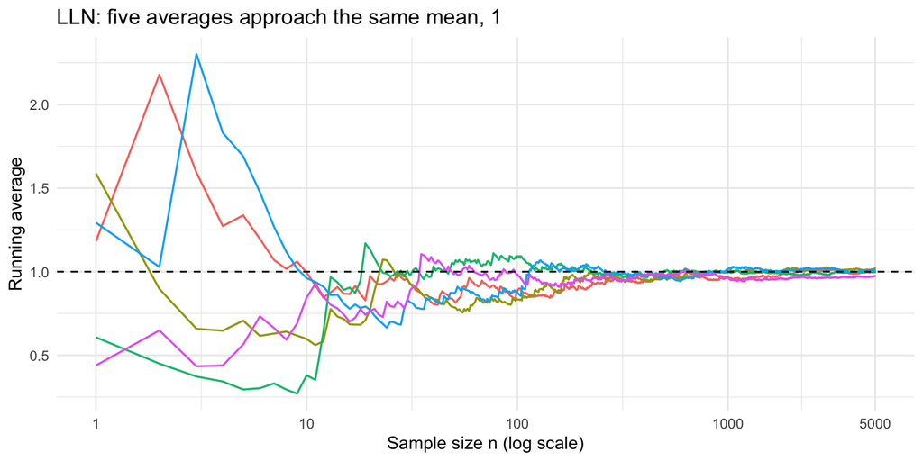

```r
withr::with_seed(101, {
  lln_n <- 5000
  lln_draws <- matrix(rexp(lln_n * 5), nrow = lln_n)
  lln_means <- apply(lln_draws, 2, cumsum) / seq_len(lln_n)
  lln_data <- as_tibble(lln_means, .name_repair = "unique") |>
    mutate(n = seq_len(lln_n)) |>
    pivot_longer(-n, names_to = "sample", values_to = "average")
  print(ggplot(lln_data, aes(n, average, color = sample)) +
    geom_line(linewidth = 0.6) +
    geom_hline(yintercept = 1, linetype = 2) +
    scale_x_log10(breaks = c(1, 10, 100, 1000, 5000)) +
    labs(x = "Sample size n (log scale)", y = "Running average",
         title = "LLN: five averages approach the same mean, 1") +
    theme_minimal() + theme(legend.position = "none"))
})
```

**Python**

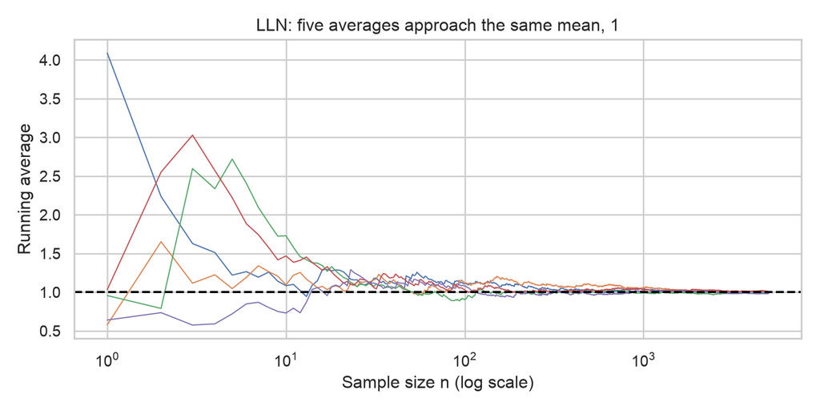

```python
lln_rng = np.random.default_rng(101)
lln_n = 5000
lln_draws = lln_rng.exponential(size=(lln_n, 5))
lln_means = np.cumsum(lln_draws, axis=0) / np.arange(1, lln_n + 1)[:, None]
fig, ax = plt.subplots(figsize=(8, 4))
ax.plot(np.arange(1, lln_n + 1), lln_means, linewidth=0.8)
ax.axhline(1, color="black", linestyle="--")
ax.set(xscale="log", xlabel="Sample size n (log scale)", ylabel="Running average",
       title="LLN: five averages approach the same mean, 1")
fig.tight_layout()
plt.show()
```

### 2.7.2 Standardized averages become Gaussian

The **central limit theorem** describes the distribution of the rescaled estimation error:
$$\frac{\sqrt n(\bar X_n-\mu)}{\sigma}\xrightarrow{d}\mathcal N(0,1).$$
Individual observations remain exponential; the CLT concerns standardized averages from repeated samples.

**R**

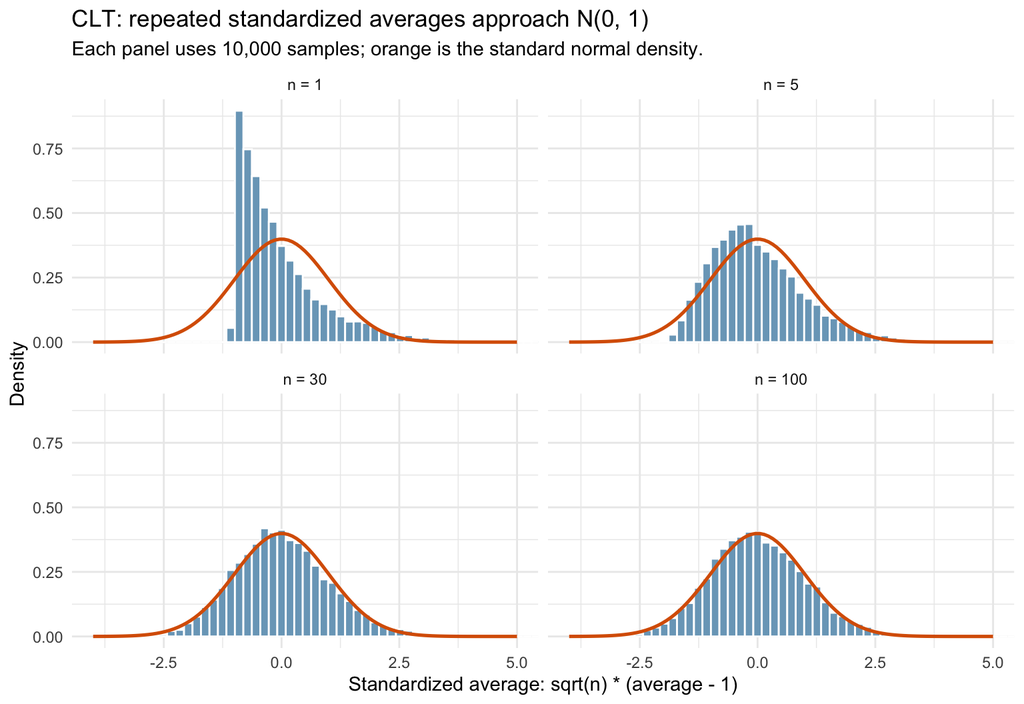

```r
withr::with_seed(102, {
  clt_sizes <- c(1, 5, 30, 100)
  clt_draws <- matrix(rexp(10000 * max(clt_sizes)), nrow = 10000)
  clt_data <- bind_rows(lapply(clt_sizes, function(n) {
    tibble(n = n, z = sqrt(n) *
      (rowMeans(clt_draws[, seq_len(n), drop = FALSE]) - 1))
  })) |>
    mutate(n = factor(n, levels = clt_sizes,
                      labels = paste("n =", clt_sizes)))
  print(ggplot(clt_data, aes(z)) +
    geom_histogram(aes(y = after_stat(density)), binwidth = 0.18,
                   fill = "#7AA6C2", color = "white") +
    geom_function(fun = dnorm, xlim = c(-4, 5),
                  color = "#D95F02", linewidth = 0.9) +
    facet_wrap(~ n, ncol = 2) + coord_cartesian(xlim = c(-4, 5)) +
    labs(x = "Standardized average: sqrt(n) * (average - 1)", y = "Density",
         title = "CLT: repeated standardized averages approach N(0, 1)",
         subtitle = "Each panel uses 10,000 samples; orange is the standard normal density.") +
    theme_minimal())
})
```

**Python**

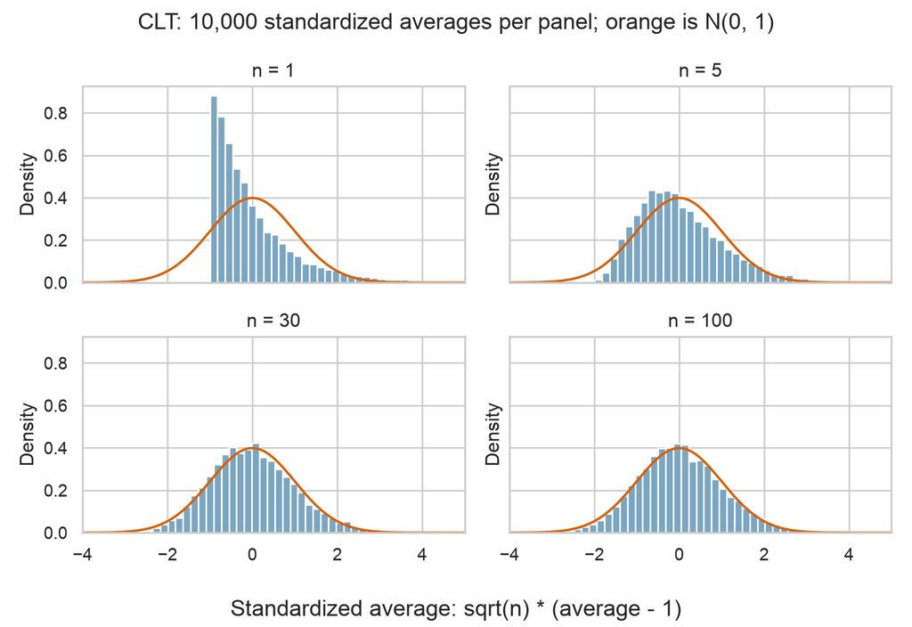

```python
clt_rng = np.random.default_rng(102)
clt_sizes = [1, 5, 30, 100]
clt_draws = clt_rng.exponential(size=(10000, max(clt_sizes)))
fig, axes = plt.subplots(2, 2, figsize=(8, 5.5), sharex=True, sharey=True)
clt_grid = np.linspace(-4, 5, 400)
for ax, n in zip(axes.flat, clt_sizes):
    clt_z = np.sqrt(n) * (clt_draws[:, :n].mean(axis=1) - 1)
    ax.hist(clt_z, bins=np.arange(clt_z.min() - 0.18, clt_z.max() + 0.18, 0.18),
            density=True, color="#7AA6C2", edgecolor="white")
    ax.plot(clt_grid, stats.norm.pdf(clt_grid), color="#D95F02")
    ax.set(title=f"n = {n}", xlim=(-4, 5), ylabel="Density")
fig.suptitle("CLT: 10,000 standardized averages per panel; orange is N(0, 1)")
fig.supxlabel("Standardized average: sqrt(n) * (average - 1)")
fig.tight_layout()
plt.show()
```

## 2.8 Bottomline

**NoteDistribution functions**

What matters in random variables is the probability of their realizations. The **tool** that always works is the **distribution function**.

- If $X$ is **discrete**, then $P[X \le k]$ characterize the variable (so does $P[X=k]$).
- If $X$ is **continuous**, the only $P[X \le x]$ does. $P[X = x]=0$ but $f(x)=\frac{\partial}{\partial x} P[X \le x]$ can be defined and serve as density, which is the continuous version of the histogram.
- If $X=(X_1, \dots, X_n)$ is **multivariate**, then look at $P[X_1 \le x_1, \dots, X_n \le x_n]$.

Simple statistics are super useful!

# 3 Random processes

Ok so until now, we have covered **random variables** in such a way that we considered one draw at a time.

**NoteThere are, however, several ways to combine them and consider higher dimensions:**

- in the **cross-section**: imagine you are interested in **height** and **weight** at the same time. This make 2 numbers. And, of course, they should be related: all other things equal, taller people should be heavier.
- in the **time** domain. Imagine you record a given quantity periodically: economic output (GDP) on a quarterly basis; sales of Adidas shoes annually, the value of Bitcoin daily, etc. You also get several values! And these can also follow interesting patterns that you might want to understand… and predict!

Because this is a course on **time-series**, we will henceforth focus on the latter.

## 3.1 Definitions & notations

Time-series are random variables indexed by time. Usually, they are written $x_t$, or $X_t$ or $y_t$ or similar notations of this kind. The index $t$ refers to *time*. The essential question in time-series is to determine the law of motion of the process, as well as its characteristics.

Most often, the process integrates some form of randomness, which is usually written $e_t$, $u_t$, $\epsilon_t$ or $\varepsilon_t$. There are two common simplifying assumptions that are made with respect to these quantities, which are sometimes referred to as *innovations* or *residuals*:

1. they are **normally distribution** (with constant Gaussian law);
2. they are **independent** from each other (i.e., $e_t$ is independent from $e_{t+1}$).

This is call the IID assumption. Under gaussian law, this is equivalent to the innovations being **uncorrelated**.

**NOTE**: in almost all models, innovations have zero means, $\mathbb{E}[e_t]=0$, hence in the case of Gaussian innovations, only the variance $\sigma^2$ is specified. We will work under these (standard) assumptions below. Let’s generate a series of $e_t$ and plot it below.

**R**

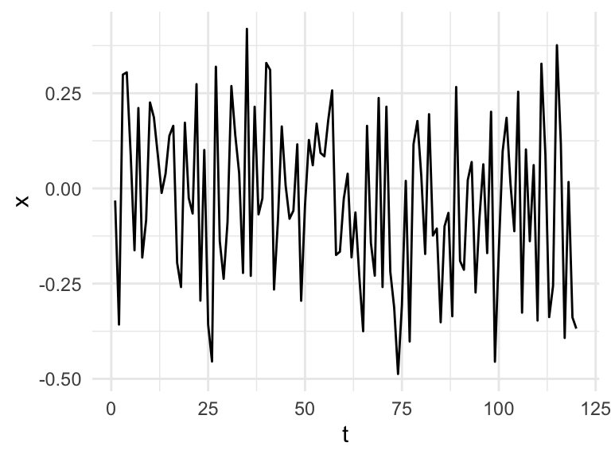

```r
N <- 120
sigma <- 0.2
x <- rnorm(N, mean = 0, sd = sigma)
data.frame(t = 1:N, x = x) |>
  ggplot(aes(x = t, y = x)) + geom_line() + theme_minimal()
```

```r
mean(x)
```

```
[1] -0.03540623
```

```r
sd(x)
```

```
[1] 0.2175779
```

**Python**

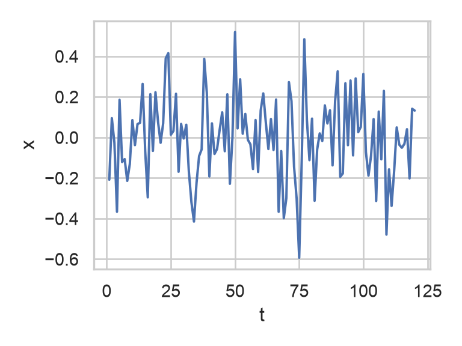

```python
N = 120
sigma = 0.2
x = rng.normal(loc=0, scale=sigma, size=N)
fig, ax = plt.subplots(figsize=(4, 3))
ax.plot(np.arange(1, N + 1), x)
ax.set(xlabel="t", ylabel="x")
fig.tight_layout()
plt.show()
```

```python
print("Mean:", np.mean(x))
```

```
Mean: -0.0038260598596661236
```

```python
print("Sample standard deviation:", np.std(x, ddof=1))
```

```
Sample standard deviation: 0.20418729281328132
```

We see that the sample averages are not too far from the parameters we chose (zero mean and 0.2 SD).